# EB3I n1 2025 scRNAseq - **Differential expression analysis**

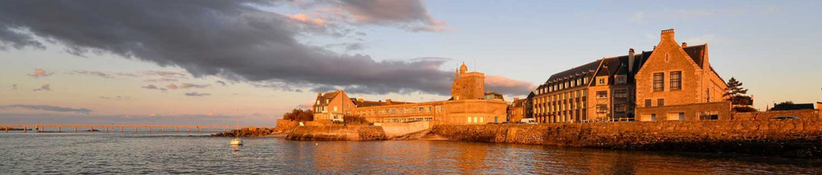

[output not shown]

# 1 Prepare the data structure

We will do the same as for former steps, just changing the session name :

## 1.1 Main directory

## 1.2 Current session

## 1.3 Input directory

## 1.4 Output directory

# 2 Reload the Seurat Object

- We can reload the object we saved at the former step

# 3 Forewords

I need three teams for this session: - Team [`Wilcoxon`](https://en.wikipedia.org/wiki/Wilcoxon_signed-rank_test) - Team [`Student`](https://en.wikipedia.org/wiki/Student%27s_t-test) - Team [`MAST`]

I will also need your help because I can’t make [DESeq2](https://bioconductor.org/packages/release/bioc/html/DESeq2.html) work correctly.

But I’m sure, that we will solve my issue: you’re in the best session here at [EB3I](https://github.com/IFB-ElixirFr/EBAII).

## 3.1 TLDR: R command lines

In this presentation, there will be screen captures for you to follow the lesson. There will also be every single R command lines.

Do not take care of the command lines if you find them too challenging.

Our goal here, is to **understand** the main mechanism of Differential Expression Analysis. R is *just a tool*.

Below are the libraries we need to perform this whole session:

```r
base::library(package = "BiocParallel")    # Optionally multithread some steps
base::library(package = "DT")              # Display nice tables in HTML
base::library(package = "ggplot2")         # Draw nice graphs and plots
base::library(package = "ggpubr")          # Draw even nicer graphs
base::library(package = "rstatix")         # Base R statistics
base::library(package = "knitr")           # Build this presentation
base::library(package = "dplyr")           # Handle big tables
base::library(package = "Seurat")          # Handle SingleCell analyses
base::library(package = "SeuratObject")    # Handle SingleCell objects for Seurat
base::library(package = "SingleCellExperiment") # Handle SingleCell file formats
base::library(package = "UpSetR")          # Nice venn-like graphs
base::library(package = "EnhancedVolcano") # Draw Volcano plot
```

Then we join layers:

```r
# join_layers_tldr

Seurat::Idents(sobj) <- sobj$orig.ident
sobj <- SeuratObject::JoinLayers(sobj)
```

Then we perform differential expression analysis:

```r
# run_dea

sobj_de <- Seurat::FindMarkers(
  # Object on which to perform DEA
  object = sobj,
  # Name of factor in condition 1
  ident.1 = "TD3A",
  # Name of factor in condition 2
  ident.2 = "TDCT"
)
```

And that’s all ! Our goal is to understand these lines, being able to write them is a bonus.

## 3.2 Purpose of this session

Up to now, we have:

1. Identified to which cell each sequenced reads come from
2. Identified to which gene each read come from
3. Identified possible bias in gene expression for each cell
4. Filtered and corrected these bias as well as we can

At the end of this session you will know:

1. how to select a differential analysis method
2. how to select the correct normalization (if any?) that must be provided to your differential analysis method
3. How to read differential expression results

## 3.3 Insight

We are wondering what’s in our dataset. Let’s have a look, with the function [`print`](https://www.rdocumentation.org/packages/base/versions/3.6.2/topics/print) form the package `base`.

```r
# print_seurat

base::print(
  # Object to display
  x = sobj
)
```

**Show output**

```
An object of class Seurat
12926 features across 3886 samples within 1 assay
Active assay: RNA (12926 features, 2000 variable features)
 3 layers present: data, counts, scale.data
 6 dimensional reductions calculated: pca, CCAIntegration, umap, RPCAIntegration, HarmonyIntegration, HarmonyStandalone
```

Let us have a look at the RNA counts for 10 cells and their annotation, with the function [`head`](https://www.rdocumentation.org/packages/utils/versions/3.6.2/topics/head) from the package `utils`.

```r
# head_seurat_counts_phase

utils::head(
  # Object to visualize
  x = sobj,
  # Number of lines to display
  n = 10
)
```

Prettier with a table in HTML :

|  | orig.ident | nCount_RNA | nFeature_RNA | log10_nCount_RNA | nCount_RNA_in_range | nFeature_RNA_in_range | percent_mt | percent_rb | percent_st | percent_mt_in_range | percent_rb_in_range | percent_st_in_range | CC_Seurat_S.Score | CC_Seurat_G2M.Score | CC_Seurat_Phase | CC_Seurat_SmG2M.Score | doublet_scds.hybrid | doublet_scDblFinder | doublet_union | doublet_viz | CCAIntegration_clusters | seurat_clusters | RPCAIntegration_clusters | HarmonyIntegration_clusters | HarmonyStandalone_clusters |
| --- | --- | --- | --- | --- | --- | --- | --- | --- | --- | --- | --- | --- | --- | --- | --- | --- | --- | --- | --- | --- | --- | --- | --- | --- | --- |
| TD3A_AAACCTGTCGAGGTAG.1 | TD3A | 1877 | 1241 | 3.273695587930092 | True | True | 0.02930207778369739 | 0.08044752264251465 | 0.03036760788492275 | True | True | True | -0.1186911827036432 | 0.0539270583226158 | G2M | -0.172618241026259 | False | False | False | singlet | 0 | 0 | 1 | 5 | 0 |
| TD3A_AAACGGGCAGTTCATG.1 | TD3A | 3093 | 1665 | 3.490800952010855 | True | True | 0.03747980613893376 | 0.1508885298869144 | 0.02907915993537965 | True | True | True | -0.03300874832143544 | -0.09198505865532144 | G1 | 0.05897631033388601 | False | False | False | singlet | 2 | 2 | 2 | 2 | 2 |
| TD3A_AAACGGGGTCACTTCC.1 | TD3A | 2232 | 1478 | 3.34908316877959 | True | True | 0.01343484102104792 | 0.08060904612628751 | 0.02866099417823556 | True | True | True | -0.06833787649927615 | -0.1767938496580376 | G1 | 0.1084559731587615 | False | False | False | singlet | 0 | 0 | 1 | 0 | 0 |
| TD3A_AAACGGGGTTCCACGG.1 | TD3A | 3011 | 1766 | 3.478999131673357 | True | True | 0.01925630810092962 | 0.1261620185922975 | 0.0249003984063745 | True | True | True | -0.03598820681465448 | -0.05681871827050949 | G1 | 0.02083051145585502 | False | False | False | singlet | 5 | 2 | 2 | 1 | 2 |
| TD3A_AAAGATGAGTCCGTAT.1 | TD3A | 1588 | 1079 | 3.201397124320451 | True | True | 0.03901825047199497 | 0.0723725613593455 | 0.03398363750786659 | True | True | True | -0.0736661662734986 | 0.02088417159989578 | G2M | -0.09455033787339438 | False | False | False | singlet | 0 | 1 | 0 | 0 | 1 |
| TD3A_AAAGATGCACACGCTG.1 | TD3A | 1609 | 1107 | 3.20682587603185 | True | True | 0.01740211311373524 | 0.05779987569919205 | 0.03604723430702299 | True | True | True | 0.03693265948963495 | 0.1046646317728384 | G2M | -0.0677319722832034 | False | False | False | singlet | 0 | 1 | 0 | 5 | 1 |
| TD3A_AAAGCAAAGGGTGTTG.1 | TD3A | 2186 | 1453 | 3.340047317661393 | True | True | 0.02560585276634659 | 0.09693644261545496 | 0.02652034750800183 | True | True | True | 0.06717925795528928 | -0.03882146953570587 | S | 0.1060007274909952 | False | False | False | singlet | 3 | 0 | 1 | 1 | 0 |
| TD3A_AAAGCAAGTCAGAATA.1 | TD3A | 13473 | 3667 | 4.12949654301666 | True | True | 0.02530987901729385 | 0.1423587916573889 | 0.0336228011578713 | True | True | True | 0.2939457735539816 | 1.27363036079376 | G2M | -0.9796845872397784 | False | False | False | singlet | 8 | 7 | 7 | 8 | 7 |
| TD3A_AAAGCAAGTTGGTGGA.1 | TD3A | 2177 | 1338 | 3.338257230246255 | True | True | 0.02203856749311295 | 0.113406795224977 | 0.03259871441689623 | True | True | True | -0.07745197730557946 | -0.08665734511866217 | G1 | 0.009205367813082718 | False | False | False | singlet | 5 | 0 | 1 | 1 | 0 |
| TD3A_AAAGTAGAGTAACCCT.1 | TD3A | 1623 | 1097 | 3.210586024905156 | True | True | 0.03203943314849045 | 0.1121380160197166 | 0.02464571780653111 | True | True | True | -0.06638196833911303 | -0.1528734803551671 | G1 | 0.0864915120160541 | False | False | False | singlet | 5 | 0 | 1 | 1 | 0 |

There are no counts, normalized or not !!

Where are they ?

In order to explore the content of `sobj`, use the function `str` from the package `utils`:

```r
# str_seurat_object

utils::str(
  # Object to explore
  object = sobj@assays
)
```

Alternatively, in RStudio, you can click on the object pane and explore manually the content of the object. If we explore the slot `assays`, then we find the counts.

You can access them with:

```r
# head_seurat_count_table

utils::head(
  # Object to visualize
  x = SeuratObject::GetAssayData(object = sobj, assay = "RNA", layer = "counts"),
  # Number of rows to display
  n = 10

  )
```

Prettier with a table in HTML :

|  | TD3A_AAACCTGTCGAGGTAG.1 | TD3A_AAACGGGCAGTTCATG.1 | TD3A_AAACGGGGTCACTTCC.1 | TD3A_AAACGGGGTTCCACGG.1 | TD3A_AAAGATGAGTCCGTAT.1 |
| --- | --- | --- | --- | --- | --- |
| Mrpl15 | 0 | 0 | 0 | 0 | 1 |
| Lypla1 | 1 | 1 | 0 | 0 | 0 |
| Gm37988 | 0 | 0 | 0 | 0 | 0 |
| Tcea1 | 0 | 2 | 1 | 1 | 0 |
| Atp6v1h | 1 | 1 | 0 | 0 | 0 |
| Rb1cc1 | 0 | 1 | 0 | 4 | 0 |
| 4732440D04Rik | 0 | 0 | 0 | 0 | 0 |
| Pcmtd1 | 0 | 0 | 0 | 0 | 0 |
| Gm26901 | 0 | 0 | 0 | 0 | 0 |
| Rrs1 | 0 | 0 | 0 | 0 | 0 |

We have one gene per line, one cell per column, and RNA counts in each row.

For the sake of this session, we won’t compare the whole dataset. It would take up to 15 minutes to complete. During the rest of this session, we will compare the Louvain clusters 8 and 10, from our integration with Harmony.

We need to re-annotate layers to do so. This is done in two steps:

1. Redefine [`Idents`](https://www.rdocumentation.org/packages/Seurat/versions/3.1.4/topics/Idents) in order to be able to call cells by their cluster names.
2. [`JoinLayers`](https://www.rdocumentation.org/packages/SeuratObject/versions/5.0.2/topics/JoinLayers) to have a single count table with both TD3A and TDCT cells from clusters 8 and 10 together.

```r
# ident_and_join_layers

Seurat::Idents(sobj) <- sobj$HarmonyStandalone_clusters
sobj <- SeuratObject::JoinLayers(sobj)
```

Let’s check if our cells are joint:

```r
# check_joint_layers

base::print(sobj)
```

**Show output**

```
An object of class Seurat
12926 features across 3886 samples within 1 assay
Active assay: RNA (12926 features, 2000 variable features)
 3 layers present: data, counts, scale.data
 6 dimensional reductions calculated: pca, CCAIntegration, umap, RPCAIntegration, HarmonyIntegration, HarmonyStandalone
```

**Question** :

- We have one gene per line, one cell per column, and RNA counts in each row.

  ```r
  # q_normscalfilt

  ## Are these counts normalized ? scaled ? filtered ?
  ```

  ```r
  # a_normscalfilt

  ## . These counts are normalized, scaled, filtered for sure.
  ##
  ## . This information is available in the seurat object itself,
  ##   within the slot `@commands`.
  ```

  See an example below:

  ```r
  # a_normscalfilt

  ## . These counts are normalized, scaled, filtered for sure.
  ##
  ## . Total counts, max value, counts per cell and number of
  ##   expressed features per cell, all have decreased.
  ##
  ## . This information is available in the seurat object itself,
  ##   within the slot `@commands`. See an example below:
  ```

  ```r
  # seurat_history

  names(sobj@commands)
  ```

  **Show output**

  ```
   [1] "NormalizeData.RNA"
   [2] "FindVariableFeatures.RNA"
   [3] "ScaleData.RNA"
   [4] "RunPCA.RNA"
   [5] "RunUMAP.RNA.CCAIntegration"
   [6] "FindNeighbors.RNA.CCAIntegration"
   [7] "RunUMAP.RNA.RPCAIntegration"
   [8] "FindNeighbors.RNA.RPCAIntegration"
   [9] "RunUMAP.RNA.HarmonyIntegration"
  [10] "FindNeighbors.RNA.HarmonyIntegration"
  [11] "RunUMAP.RNA.HarmonyStandalone"
  [12] "FindNeighbors.RNA.HarmonyStandalone"
  [13] "FindClusters"
  ```

  **However**, please remember that :
  - Counts in the slot `count` are **raw counts**
  - **Normalized counts** are in the slot `data`
  - **scaled** data are in the slot `scaled.data` (this one was damn obvious).

  And it you do not find that crystal-clear, I totally agree with you.
- Raw counts have many, so many zeros …

  ```r
  # q_sozero

  ## Is it normal to you ?
  ```

  ```r
  # a_sozero

  ## . The large number of null counts is completely normal for this
  ##   "droplet" technology. In maths/stats, we talk about "matrix sparcity",
  ##   i.e a table with lots (lots!) of zeros.
  ```

- And count values are so low …

  ```r
  # q_lowcounts

  ## Why ? Is it because we downsampled the read depth for this training ?
  ```

  ```r
  # a_lowcounts

  ## . No. Once again, this is intrinsic to the technology used.
  ##
  ## . If the data were to be downsampled, we would had done this by cropping
  ##   the count matrix over a small chromosome, or a reduced gene est, not
  ## by lowering the global amount of reads (depth).
  ```

# 4 Select a DE method

## 4.1 Available methods

[Seurat](https://satijalab.org/seurat/articles/de_vignette) let us use multiple differential analysis methods with its function [`FindMarkers`](https://satijalab.org/seurat/reference/findmarkers).

1. [wilcox](https://www.rdocumentation.org/packages/rstatix/versions/0.7.1): The wilcoxon test tests the mean of expression and looks for a difference in these means.
2. [MAST](https://www.bioconductor.org/packages/release/bioc/vignettes/MAST/inst/doc/MAST-Intro.html): This tool has been built for Single Cell. It is based on a statistical model called [“Hurdle Model”](https://en.wikipedia.org/wiki/Hurdle_model), which excells with data that contains lots of zeros (which is our case in Single Cell RNA-Seq: most of the genes are *not* expressed.)
3. [DESeq2](https://bioconductor.org/packages/release/bioc/vignettes/DESeq2/inst/doc/DESeq2.html#recommendations-for-single-cell-analysis): This tool has originally been built for bulk RNA-Seq but now includes specific functions for Single Cell. It performs well when counts are highly variable or when you wand to compare a handful of cells.
4. [t-test](https://www.rdocumentation.org/packages/stats/versions/3.6.2/topics/t.test): The t-test uses a comparison of means to assess differential expression probability.
5. [roc](https://en.wikipedia.org/wiki/Receiver_operating_characteristic): In this method, an AUC value of `1` means that expression values for this gene alone can perfectly classify the two groupings, i.e : each of the cells in “cells.1” (condition 1) exhibit a higher level than each of the cells in “cells.2” (condition 2). An AUC value of `0` also means there is perfect classification, but in the opposite direction (higher in condition 2 than in 1). A value of `0.5` implies that the gene has no predictive power to classify the two groups.

The main question now is **how to choose the right test ??**

**Spoilers** : there are no option better than another in all ways ! Thank you for your attention, you can go back home now.

From Soneson & Robinson (2018) Nature Methods:

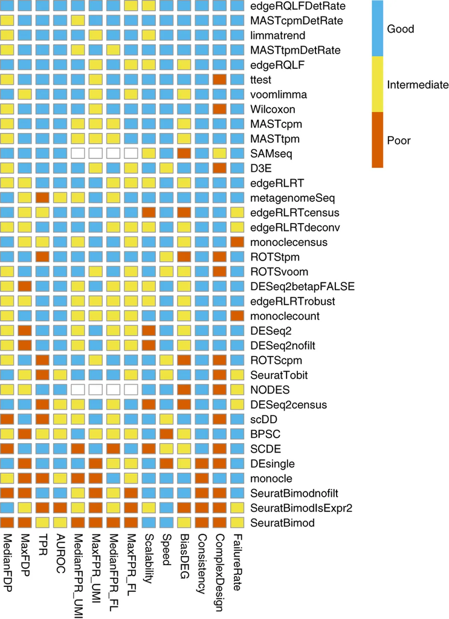

Here, researchers have designed an **artificial dataset** where they knew in advance the list of differentially expressed genes. They have used all these algorithms and consigned the results.

1. `DESeq2`, `Limma` seem to have a higher number of false positives (genes identified as differentially expressed while they were actually not.)
2. `Wilcoxon` seems to be better in general.
3. `MAST` performs well in absolute

`ANOVA` was not present in this study (but probably would have performed similarly to `t-test`.